# MTH6139 Time Series

Coursework 1_220454696

Sujin Han

17/03/2025

# Introduction

This coursework trains us how to predict data (time series) using the **Meta’s Prophet** forecasting system.

This technique can be used to forecast many different types of time series, although data sets with more than 100 points are suggested for meaningful results. This page will use *K-pop Google Trends* data from the previous five years.

As a Korean student in London, I believed that K-pop had positively enhanced awareness of Korea, making me feel more at ease while living in a foreign country. This motivated me to investigate the Google trend over the last five years, aroused my interest in what the future holds for the next six months.

# Section 1: Meta’s Prophet

Let’s try Meta’s Prophet first to get familiar with it, as shown on the following page.

https://facebook.github.io/prophet/docs/quick_start.html#r-api

The process written in the site is as follows.

> 📘 **Note**

> The following codes are the same as those given on the site above. It is just for those who can’t access the site.

```r
library("prophet")
```

```r
df <- read.csv('https://raw.githubusercontent.com/facebook/prophet/main/examples/example_wp_log_peyton_manning.csv')

n <- prophet(df, daily.seasonality=TRUE)

future <- make_future_dataframe(n, periods = 365)
# This takes the n and a number of periods
# to forecast and produces a suitable dataframe

tail(future)
```

```
##              ds
## 3265 2017-01-14
## 3266 2017-01-15
## 3267 2017-01-16
## 3268 2017-01-17
## 3269 2017-01-18
## 3270 2017-01-19
```

```r
forecast <- predict(n, future)

tail(forecast[c('ds', 'yhat', 'yhat_lower', 'yhat_upper')])
```

```
##              ds     yhat yhat_lower yhat_upper
## 3265 2017-01-14 7.825775   7.163717   8.571846
## 3266 2017-01-15 8.207571   7.532874   8.901009
## 3267 2017-01-16 8.532591   7.791146   9.253058
## 3268 2017-01-17 8.320005   7.618470   9.036320
## 3269 2017-01-18 8.152624   7.444534   8.876530
## 3270 2017-01-19 8.164568   7.437058   8.883859
```

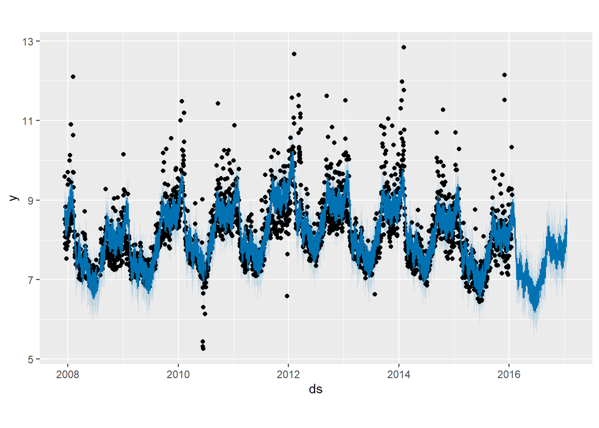

```r
plot(n, forecast)
```

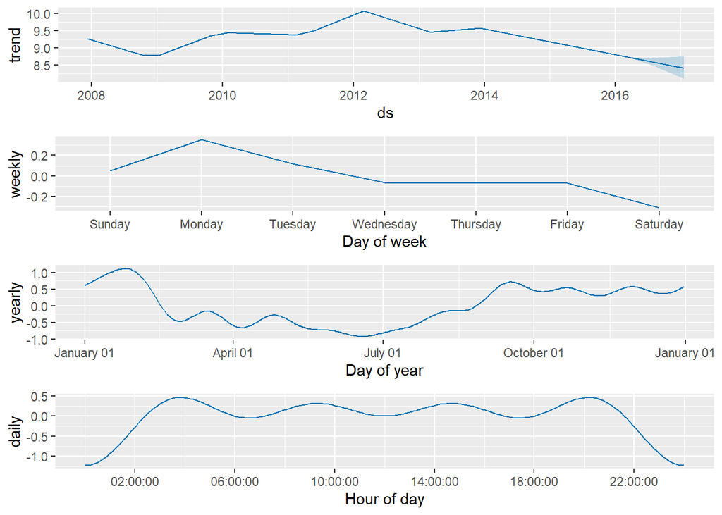

```r
prophet_plot_components(n, forecast)
```

```r
# Following command shows the forecast broken down into
# trend, weekly seasonality, and yearly seasonality
```

```r
dyplot.prophet(n, forecast)
```

[interactive chart not shown]

After this process, you can create the github page showing the works done.

## Mathematical Model of Prophet

Prophet decomposes a time series as $y(t) = g(t) + s(t) + h(t) + \epsilon_t$.

Where:

- $g(t)$ meaning the *trend*
- $s(t)$ meaning *seasonality*
- $h(t)$ meaning *holiday effects*
- $\epsilon_t$ meaning *error term*

# Section 2: Analysing the dataset using Prophet

## 2.1 Dataset

```r
library(ggplot2)
library(dplyr)
library(lubridate)
library(zoo)
```

- **Loading the dataset**

```r
Kpop <- read.csv("data/K-pop_Google Trends.csv", skip = 1, stringsAsFactors = FALSE)
```

- **Rename columns**

```r
colnames(Kpop) <- c("ds","y")
```

- **Converting date columns into yearmon format**

> 📘 **Note**

> This is just to see the dates in a vector form.

```r
Kpop_ts <- ts(Kpop$ds, start = c(2020, 3), frequency = 52)

dates <- time(Kpop_ts)
dates <- as.yearmon(dates)
```

Now, try the command below to check the result.

```r
print(dates)
```

- **Converting yearmon format back to Date format**

> 📘 **Note**

> It is needed to apply the dataset into the Prophet.

```r
Kpop$ds <- as.Date(Kpop$ds)
```

- **Structure of the data**

```r
str(Kpop)
```

```
## 'data.frame':    262 obs. of  2 variables:
##  $ ds: Date, format: "2020-03-15" "2020-03-22" ...
##  $ y : int  47 47 48 49 49 52 54 49 43 43 ...
```

```r
summary(Kpop)
```

```
##        ds                   y
##  Min.   :2020-03-15   Min.   : 42.00
##  1st Qu.:2021-06-14   1st Qu.: 52.00
##  Median :2022-09-14   Median : 57.00
##  Mean   :2022-09-14   Mean   : 58.06
##  3rd Qu.:2023-12-15   3rd Qu.: 63.00
##  Max.   :2025-03-16   Max.   :100.00
```

- **Basic Plot**

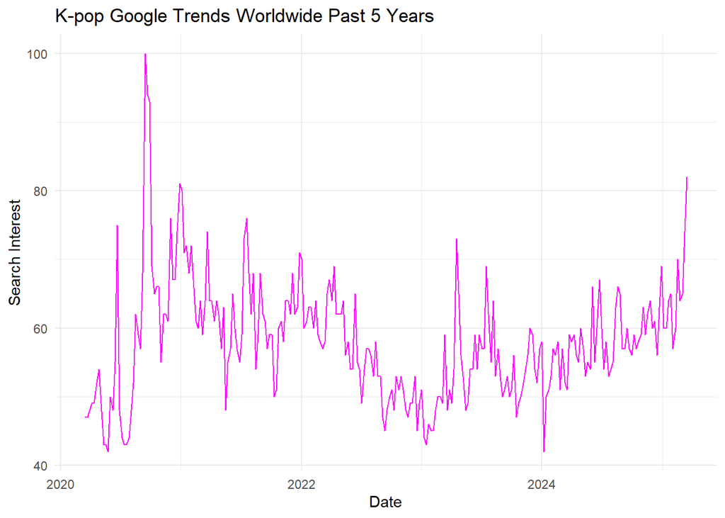

```r
ggplot(Kpop, aes(x = ds, y = y)) +
    geom_line(color = "magenta") +
    labs(title = "K-pop Google Trends Worldwide Past 5 Years",
         x = "Date", y = "Search Interest") + theme_minimal()
```

- **Seasonality**

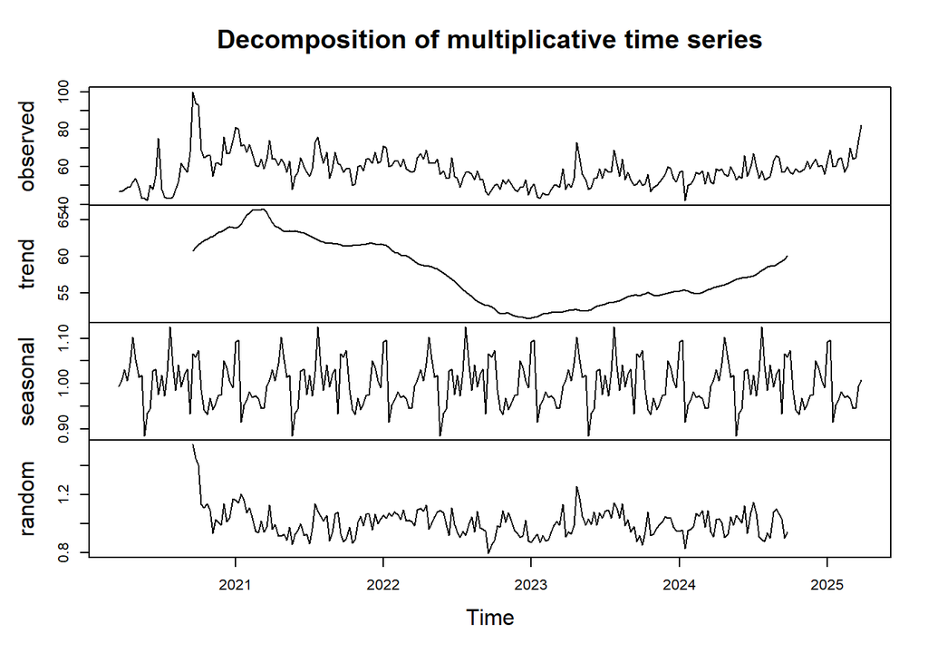

```r
ts_Kpop <- ts(Kpop$y, start = c(2020, 12), frequency = 52)

decomp <- decompose(ts_Kpop, type = "multiplicative")

plot(decomp)
```

## 2.2 Apply Prophet Model

```r
#Empty the model
model <- prophet()
```

- **Fit the model**

```r
model <- fit.prophet(model, Kpop)
```

- **Future dataframe forecasting**

```r
# Next 6 months
future <- make_future_dataframe(model, periods = 26, freq = "week")

# Next 1 Year
future1 <- make_future_dataframe(model, periods = 52, freq = "week")
```

- **Predictions**

```r
# Next 6 months
forecast <- predict(model, future)

# Next 1 Year
forecast1 <- predict(model, future1)
```

- **Plot of Forecast**

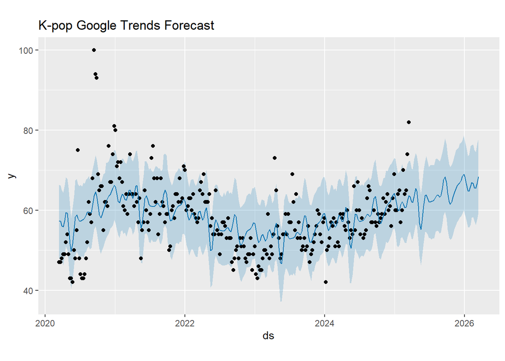

```r
# For Next 1 Year
plot(model, forecast1) + ggtitle("K-pop Google Trends Forecast")
```

- **Trend and Seasonality Analysis**

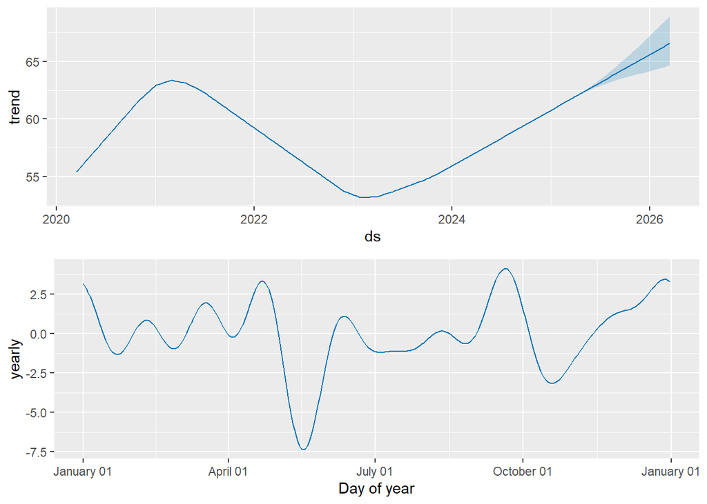

```r
# For next 1 Year
prophet_plot_components(model, forecast1)
```

- **Linear Regression**

```r
lm_model <- lm(y ~ ds, data = Kpop)

summary(lm_model)
```

```
##
## Call:
## lm(formula = y ~ ds, data = Kpop)
##
## Residuals:
##     Min      1Q  Median      3Q     Max
## -17.418  -5.369  -0.241   4.573  40.763
##
## Coefficients:
##              Estimate Std. Error t value Pr(>|t|)
## (Intercept) 89.102321  19.540921   4.560 7.89e-06 ***
## ds          -0.001613   0.001015  -1.589    0.113
## ---
## Signif. codes:  0 '***' 0.001 '**' 0.01 '*' 0.05 '.' 0.1 ' ' 1
##
## Residual standard error: 8.696 on 260 degrees of freedom
## Multiple R-squared:  0.009622,   Adjusted R-squared:  0.005813
## F-statistic: 2.526 on 1 and 260 DF,  p-value: 0.1132
```

- **Regression Line with Basic Plot of time series**

[figure not shown]

```r
ggplot(Kpop, aes(x = ds, y = y)) + geom_line(color = "magenta") + geom_smooth(method = "lm", color = "lightblue", se = FALSE) + labs(title = "K-pop Google Trends with Linear Trend",
         x = "Date", y = "Search Interest") + theme_minimal()
```

# **Comments**

## Basic Plot with Regression Line

As shown in the graph above, the trend seems to vary a lot.

To stick out some points:

- The big K-pop group released songs during mid-2020, causing a sudden surge, and many new K-pop groups also debuted, such as *aespa* and *ENHYPEN*.
- The graph seems to decrease during 2022, assuming the main reason for it is because of the announcement that the most popular group, *BTS*, is starting their military service.
- Graph increases when the awards ceremony, such as *MAMA*, *MMA*, or *Grammy Awards*, is held.

As shown above, the K-pop Google trend depends on:

- Major K-pop Events or releases
- Military Enlistment
- Online concerts or events
- etc.

The linear trend line (light blue line) shows whether the trend is decreasing or increasing in the long term. This line seems to be decreasing. We don’t know the exact reason, but we can assume it’s because of *BTS*’s military service or other groups’ scandals.

## K-pop Google Trends Forecast

- The impact of *BTS*’s and *BLACKPINK*’s global expansion can be seen in both increasing search volume from 2020 to 2021 and decreasing search volume from 2021 to 2023.
- Search volume has increased and is expected to increase since 2023, with the assumption that:
  - global success of new groups *(ex. ‘Cupid’ by FIFTY FIFTY, NewJeans)*
  - K-pop’s expansion into the fashion industry
  - Engagement of Social Media & Digital Platform

## Trend and Seasonality Analysis

**Trend Analysis (First Graph)**

**Yearly Seasonality Analysis (Second Graph)**

The graph shows seasonal tendencies.

# Conclusion

This analysis used Prophet to forecast the K-pop Google trend.